# Wine Analysis Using R

Mason Krug

5/1/2021

# Introduction to the Data

List of packages used in this project:

```r
# This will simply print the libraries used

library(ggplot2)
library(gridExtra)
library(ggcorrplot)
```

> **Data Introduction**: The data set that will be analyzed consists of 1599 entries of information about red wine. Variables that will be analyzed include quality, alcohol content, pH levels, residual sugar content, and more.

# Univariate Plots Section

> **Structure of the Data**: Here we can see the structure that the CSV file takes. It consists of the following variables. Quality of the wine is rated from 1 - 10 and alcohol represents alcohol level as a percentage. This data set consists of 13 variables to explore.

```
## 'data.frame':    1599 obs. of  13 variables:
##  $ X                   : int  1 2 3 4 5 6 7 8 9 10 ...
##  $ fixed.acidity       : num  7.4 7.8 7.8 11.2 7.4 7.4 7.9 7.3 7.8 7.5 ...
##  $ volatile.acidity    : num  0.7 0.88 0.76 0.28 0.7 0.66 0.6 0.65 0.58 0.5 ...
##  $ citric.acid         : num  0 0 0.04 0.56 0 0 0.06 0 0.02 0.36 ...
##  $ residual.sugar      : num  1.9 2.6 2.3 1.9 1.9 1.8 1.6 1.2 2 6.1 ...
##  $ chlorides           : num  0.076 0.098 0.092 0.075 0.076 0.075 0.069 0.065 0.073 0.071 ...
##  $ free.sulfur.dioxide : num  11 25 15 17 11 13 15 15 9 17 ...
##  $ total.sulfur.dioxide: num  34 67 54 60 34 40 59 21 18 102 ...
##  $ density             : num  0.998 0.997 0.997 0.998 0.998 ...
##  $ pH                  : num  3.51 3.2 3.26 3.16 3.51 3.51 3.3 3.39 3.36 3.35 ...
##  $ sulphates           : num  0.56 0.68 0.65 0.58 0.56 0.56 0.46 0.47 0.57 0.8 ...
##  $ alcohol             : num  9.4 9.8 9.8 9.8 9.4 9.4 9.4 10 9.5 10.5 ...
##  $ quality             : int  5 5 5 6 5 5 5 7 7 5 ...
```

> **Data Summary**: Below is a summary of the data from the CSV file. Here we can understand a bit more about each variable and the spread of each variable.

```
##        X          fixed.acidity   volatile.acidity  citric.acid
##  Min.   :   1.0   Min.   : 4.60   Min.   :0.1200   Min.   :0.000
##  1st Qu.: 400.5   1st Qu.: 7.10   1st Qu.:0.3900   1st Qu.:0.090
##  Median : 800.0   Median : 7.90   Median :0.5200   Median :0.260
##  Mean   : 800.0   Mean   : 8.32   Mean   :0.5278   Mean   :0.271
##  3rd Qu.:1199.5   3rd Qu.: 9.20   3rd Qu.:0.6400   3rd Qu.:0.420
##  Max.   :1599.0   Max.   :15.90   Max.   :1.5800   Max.   :1.000
##  residual.sugar     chlorides       free.sulfur.dioxide total.sulfur.dioxide
##  Min.   : 0.900   Min.   :0.01200   Min.   : 1.00       Min.   :  6.00
##  1st Qu.: 1.900   1st Qu.:0.07000   1st Qu.: 7.00       1st Qu.: 22.00
##  Median : 2.200   Median :0.07900   Median :14.00       Median : 38.00
##  Mean   : 2.539   Mean   :0.08747   Mean   :15.87       Mean   : 46.47
##  3rd Qu.: 2.600   3rd Qu.:0.09000   3rd Qu.:21.00       3rd Qu.: 62.00
##  Max.   :15.500   Max.   :0.61100   Max.   :72.00       Max.   :289.00
##     density             pH          sulphates         alcohol
##  Min.   :0.9901   Min.   :2.740   Min.   :0.3300   Min.   : 8.40
##  1st Qu.:0.9956   1st Qu.:3.210   1st Qu.:0.5500   1st Qu.: 9.50
##  Median :0.9968   Median :3.310   Median :0.6200   Median :10.20
##  Mean   :0.9967   Mean   :3.311   Mean   :0.6581   Mean   :10.42
##  3rd Qu.:0.9978   3rd Qu.:3.400   3rd Qu.:0.7300   3rd Qu.:11.10
##  Max.   :1.0037   Max.   :4.010   Max.   :2.0000   Max.   :14.90
##     quality
##  Min.   :3.000
##  1st Qu.:5.000
##  Median :6.000
##  Mean   :5.636
##  3rd Qu.:6.000
##  Max.   :8.000
```

# Univariate Analysis

> **Histogram of Wine Quality**: Here we can see that a majority of the wine has a quality of 5 or 6 with a handfull of wines labeled as 7.

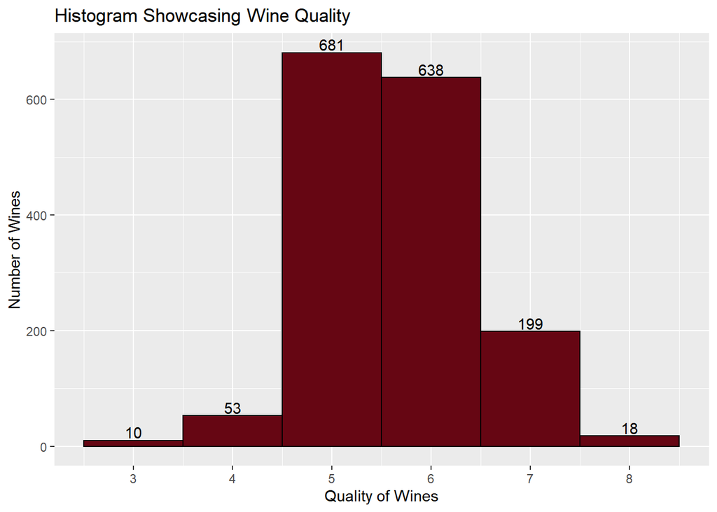

```
##
##   3   4   5   6   7   8
##  10  53 681 638 199  18
```

> **Further Exploration**: Here I want to graphically represent a handful of vaiables. I want to see if there is any approximation to a normal distribution.

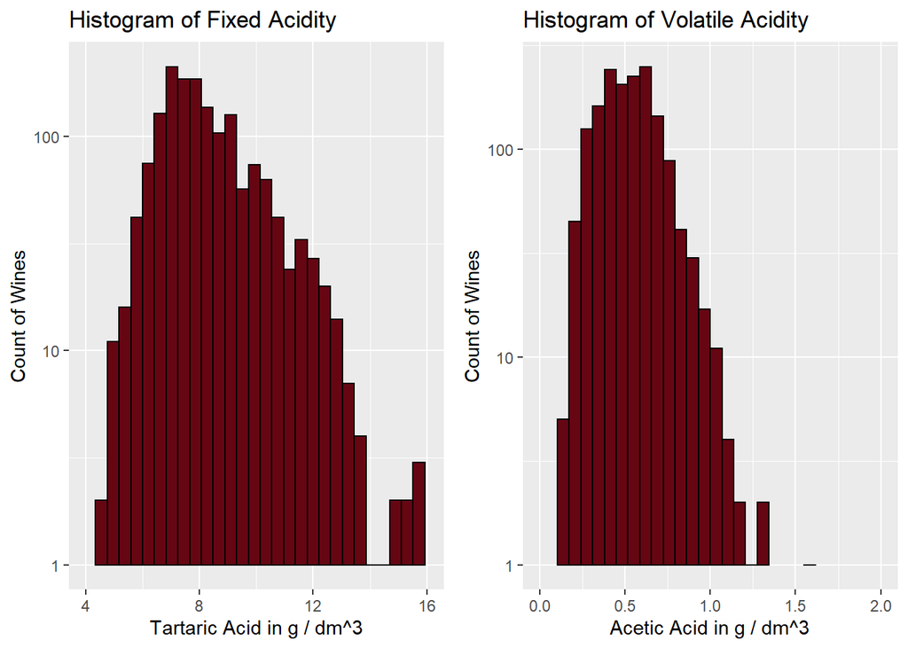

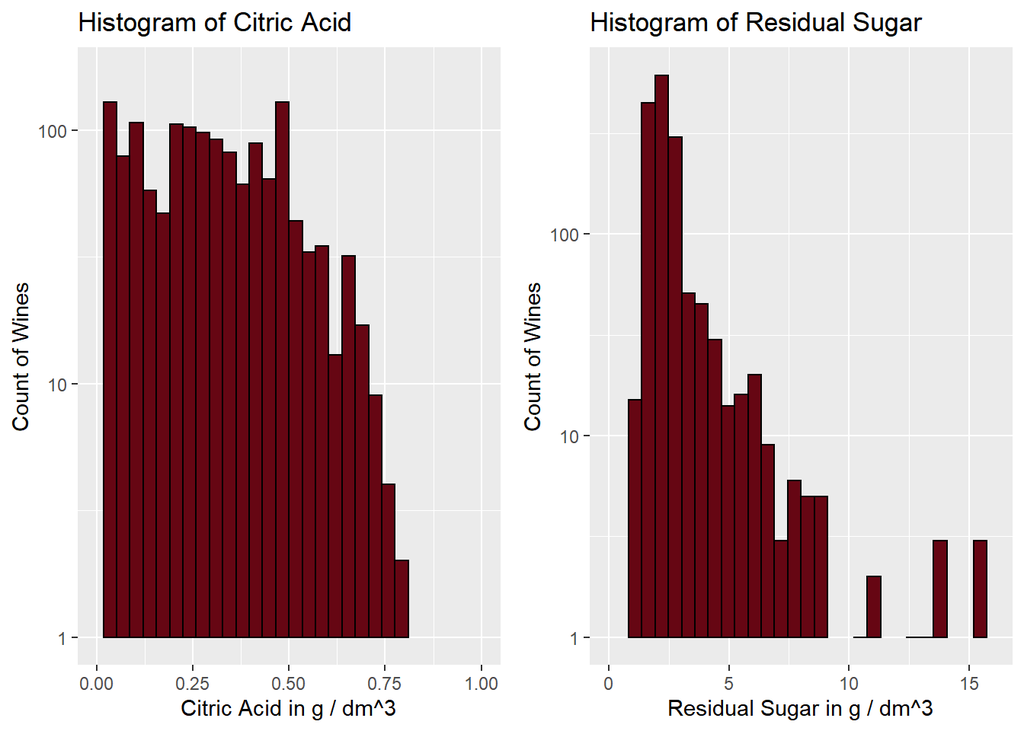

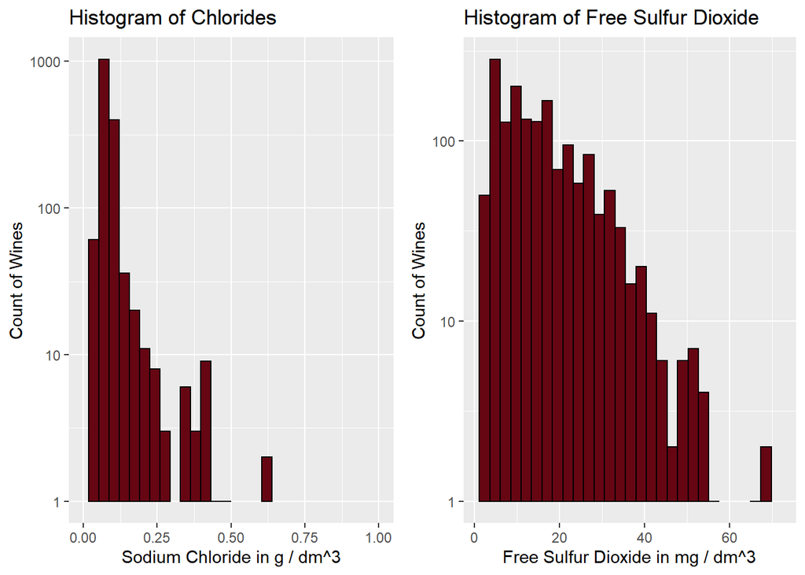

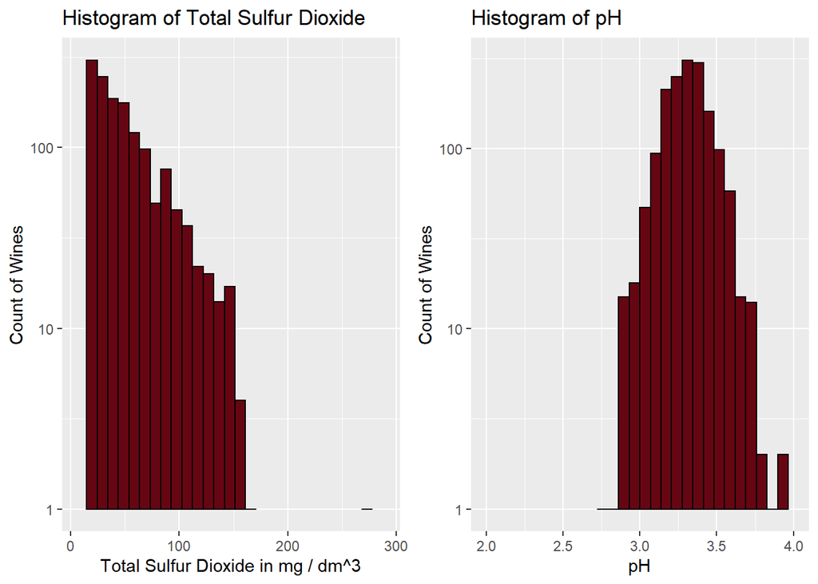

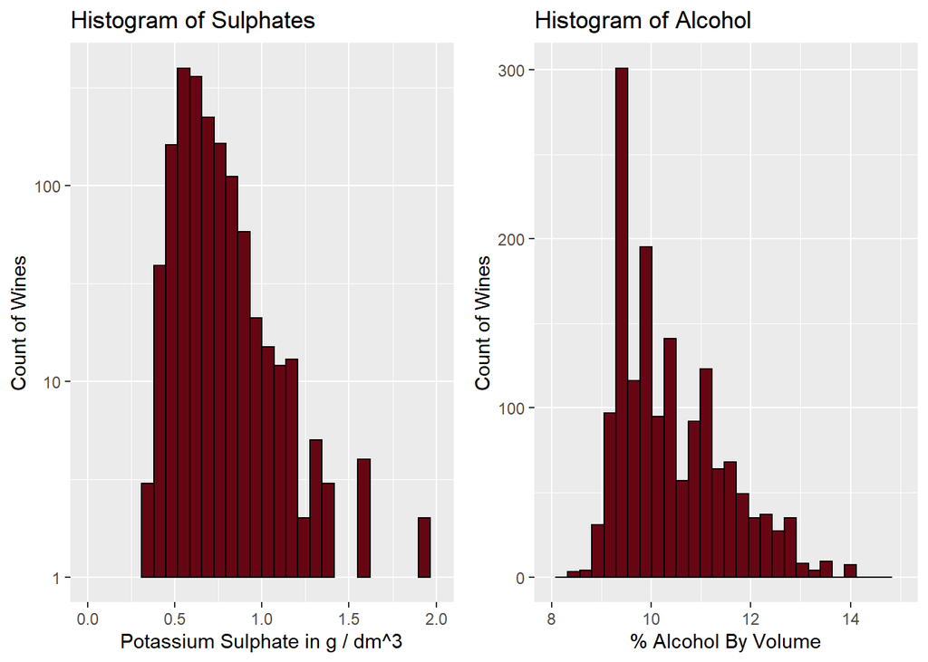

> **Logarithmic Exploration**: Many of the above histograms are close to a normal distribution. Let’s apply a logarithmic function to the above histograms to better approximate a normal distribution.

[figure not shown]

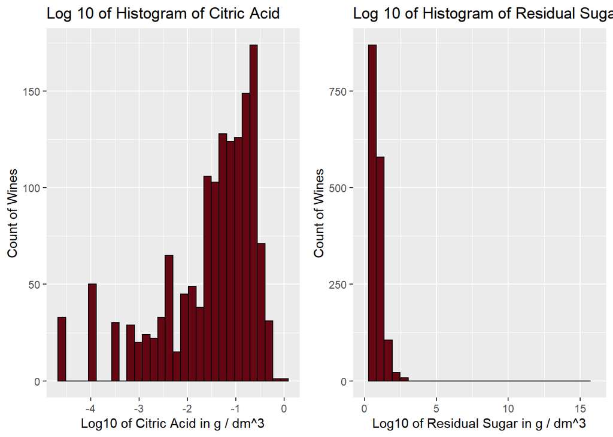

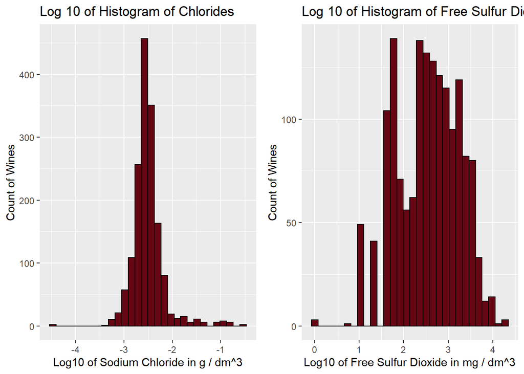

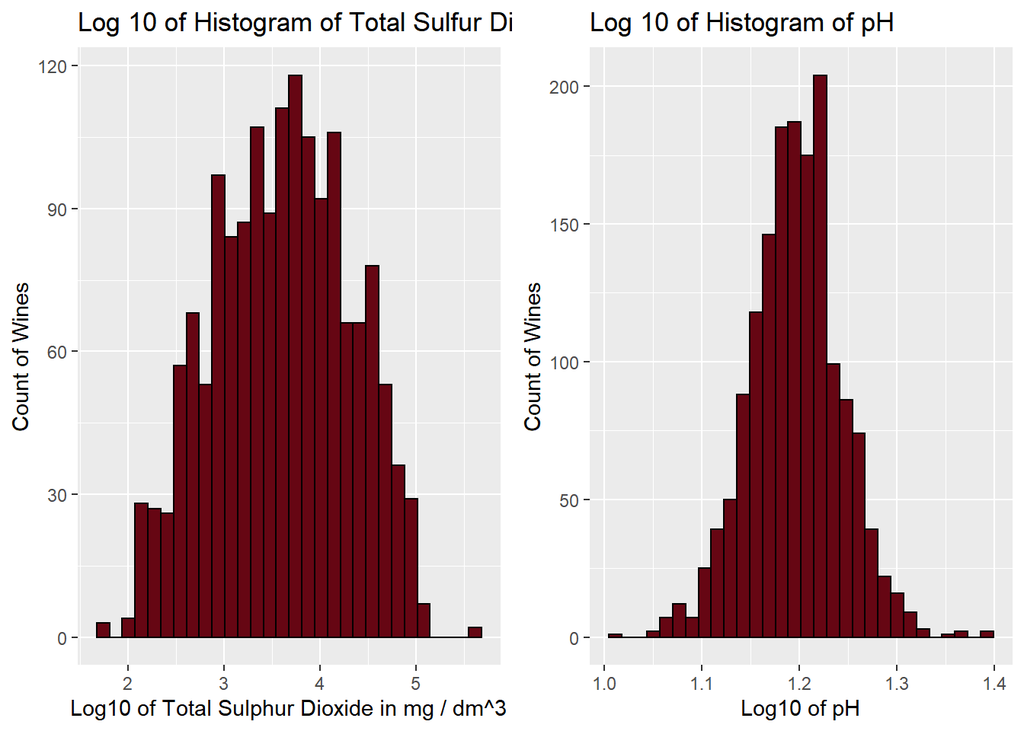

[figure not shown]

### What is the structure of your dataset?

> The data set is composed of 1599 entries expanding 13 variables.

### What is/are the main feature(s) of interest in your dataset?

> I am interested in the quality of wine and alcohol content as they relate to other variables in the dataset.

### What other features in the dataset do you think will help support your investigation into your feature(s) of interest?

> I believe sugar content will play a large role in perceived quality and I believe it will be inversely related to alcohol content. Yeast consumes sugar to produce alcohol so it stands to reason that the more alcohol content a wine has, the less sugar it will have.

### Did you create any new variables from existing variables in the dataset?

> I created a categorical variable from the quality of wine, where the 1-10 rating is labeled as follows:
- 9 and 10 are Superb
- 8 is Exceptional
- 7 is Great
- 6 is Good
- 5 is Acceptable
- 4 is Mediocre
- 3 and 2 are Bad
- 1 is Nasty

### Of the features you investigated, were there any unusual distributions? Did you perform any operations on the data to tidy, adjust, or change the form of the data? If so, why did you do this?

> I wanted to compare the count of wines against a single variable to see if there was a relationship to a normal distribution. Fixed Acidity, Volatile Acidity, pH, Sulphate Levels, and Alcohol content were roughly normal in distribution. Sulfur levels and Free Sulphur Dioxides approximated the right half of a normal distribution however they had a handful of outliers. Residual Sugar levels approximated a normal distribution however also showed a notable number of outliers on the right-hand side.

# Bivariate Analysis

### Plot One

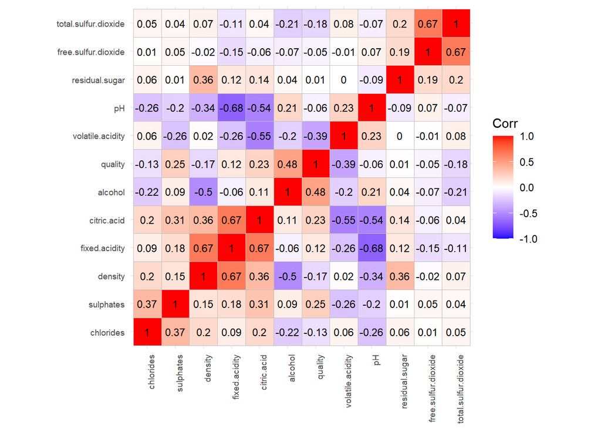

### Plot Two

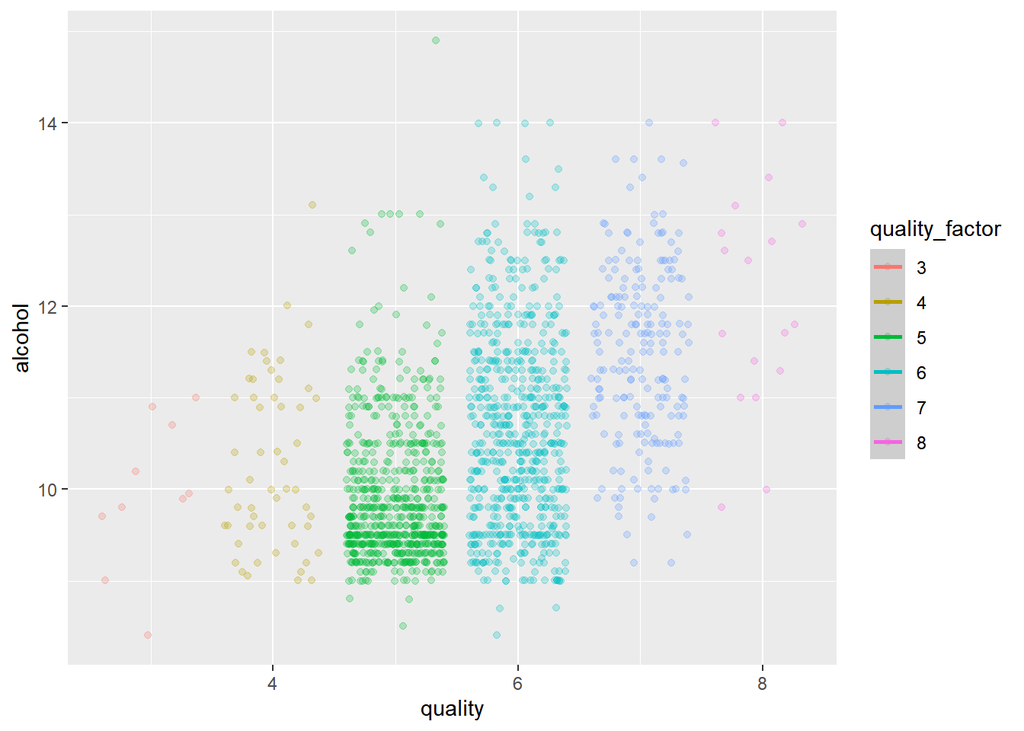

### Plot Three

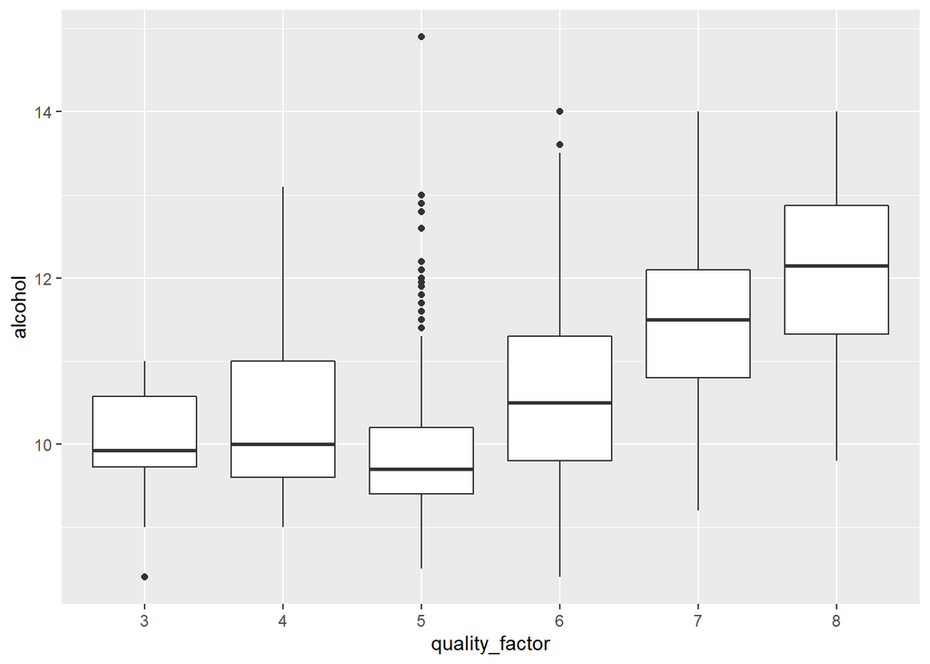

# Multivariate Analysis

### Plot One

```
## <ScaleContinuous>
##  Range:
##  Limits:    0 --    1
```

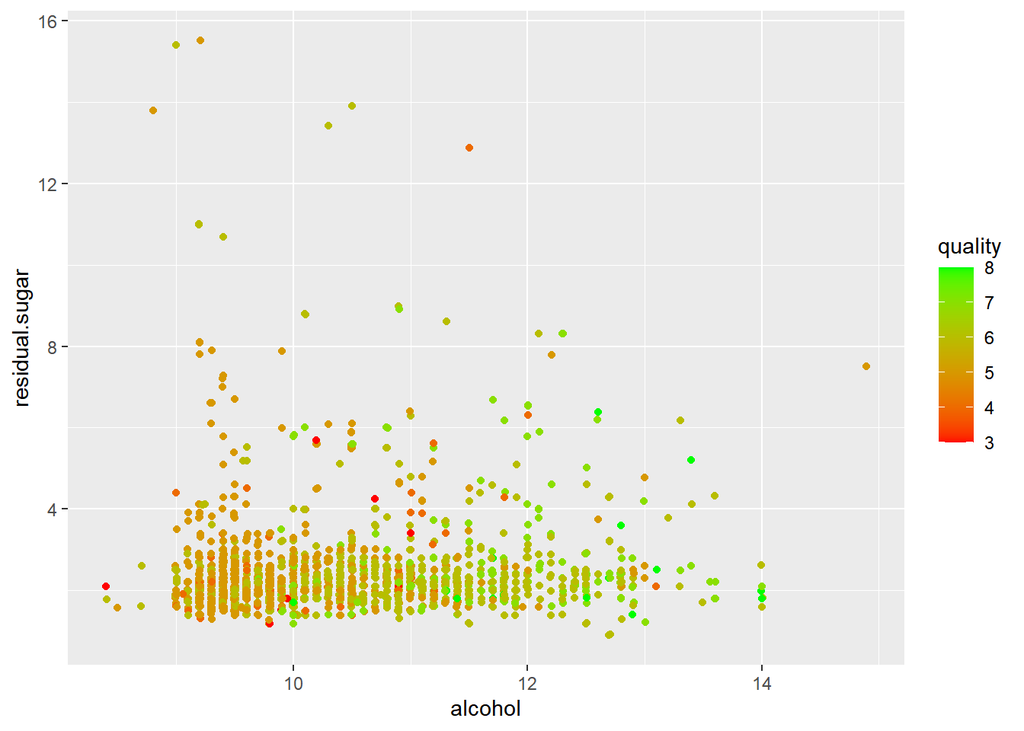

### Description One

> My initial assumption about alcohol content and residual sugar level appears to be incorrect. There is a very weak relationship between the amount of alcohol in these wine samples and the residual sugar level. Residual sugar level is most strongly correlated with density and the strongest relationship that density has with another variable is fixed accidity. Let’s explore that below.

### Plot Two

```
## <ScaleContinuous>
##  Range:
##  Limits:    0 --    1
```

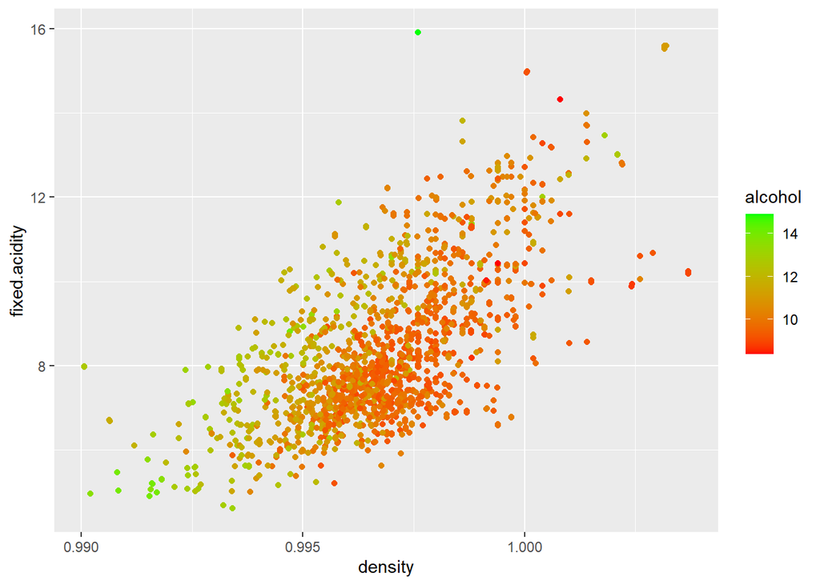

### Description Two

> Here we can see that strong relationships explained above. Density correlates with fixed acidity at **r = 0.67** and fixed alcohol content correlates strongest with density at **r = -0.50**. Below we will visually investigate the variable quality.

### Plot Three

```
## <ScaleContinuous>
##  Range:
##  Limits:    0 --    1
```

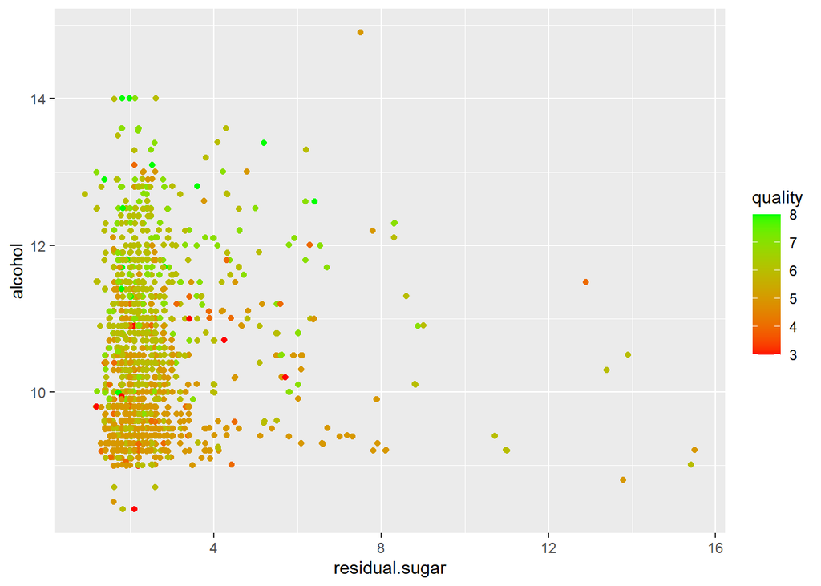

### Description Three

> Residual sugar has a notable amount of outliers. Barring the outliers, the quality of the wine increases with alcohol content. As alcohol content increases, the spread of residual sugar tends to decrease however outliers strongly influence that correlation coefficient.

### Plot Four

```
## <ScaleContinuous>
##  Range:
##  Limits:    0 --    1
```

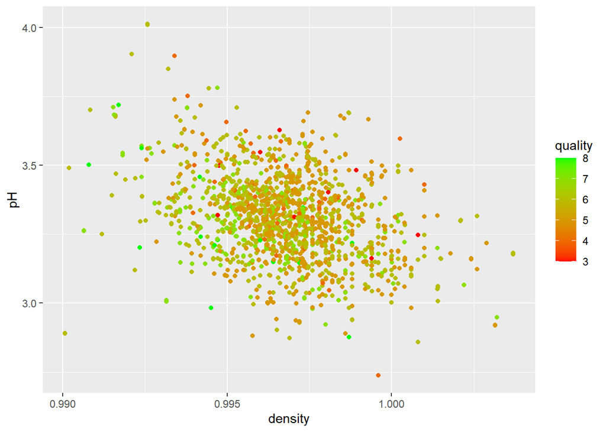

# Summary of Plots

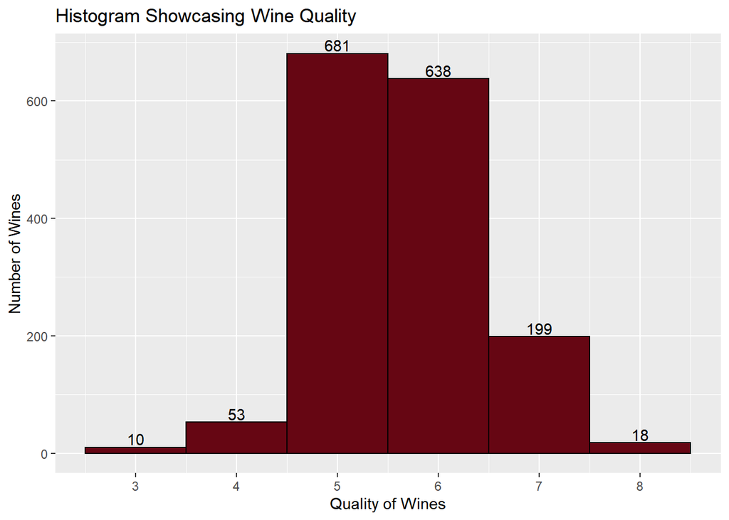

```
##
##   3   4   5   6   7   8
##  10  53 681 638 199  18
```

> I find it interesting to note how closely this sample approximates a normal distribution. I suspect that if wine ratings had a smaller interval value (ie rating in increments of 0.5) that this would more approximate a normal distribution.

```
## <ScaleContinuous>
##  Range:
##  Limits:    0 --    1
```

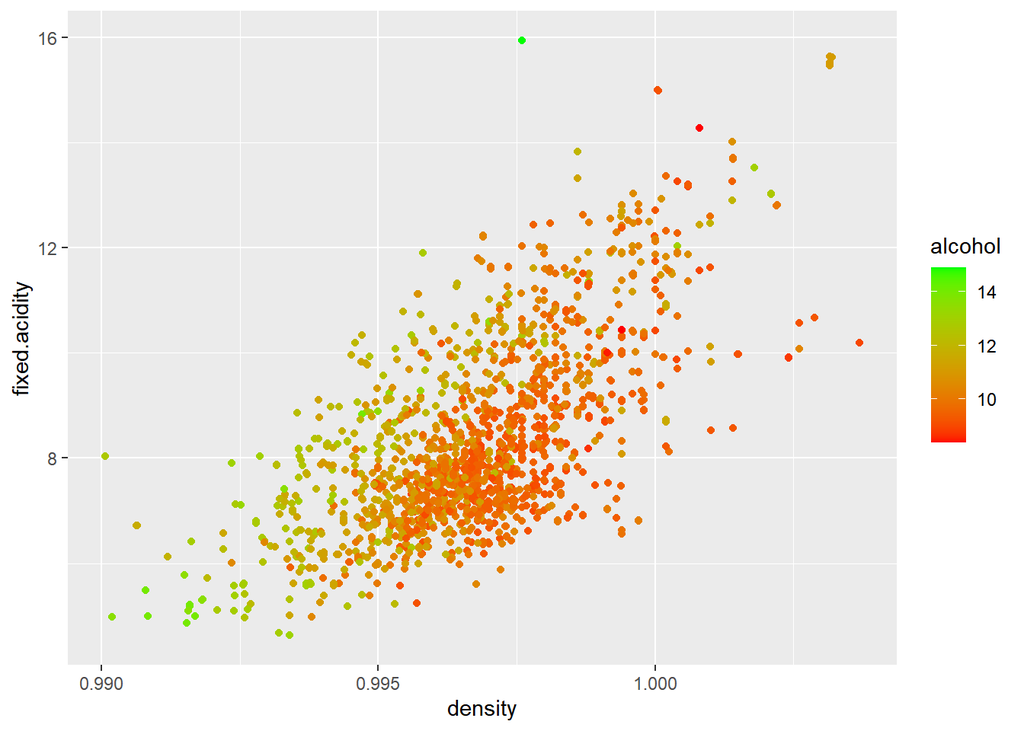

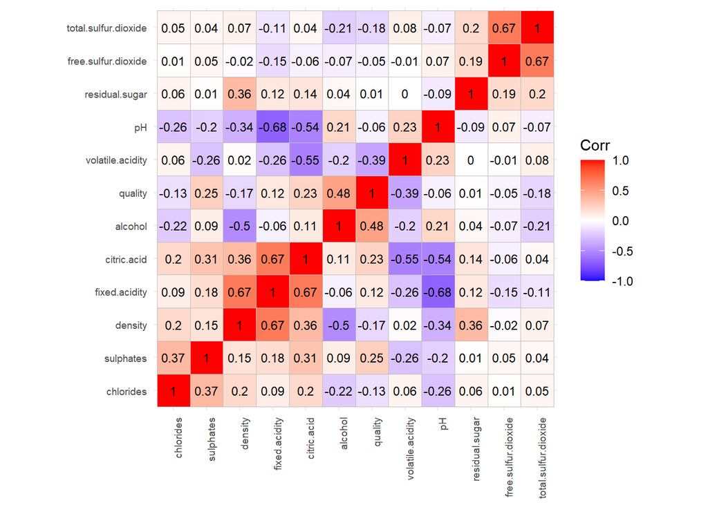

> I would like to touch on this correlation chart once more. It makes me wonder why certain variables about these wines were chosen to be measured. My guess is that they are important for the taste of wines and contribute to qualities of a wine. However, many variables have a weak relationship with each other which makes me think that, from an analytical perspective, they do not serve much pupose. I suspect that they play a large role in wine taste and so a large correlation might not be absolutely necesary.

# Reflection

> My initial assumption of an inverse relationship between residual sugar and alcohol content appears to be incorrect. While it is true that yeast consumes sugar to create alcohol, it appears that there are more factors at play. I initially struggled with what variables to explore. I am not a wine connoisseur and had no idea that sulfur content, chloride levels, and citric acid content were traits of wine that were notable, let alone even measures. For future analysis, I think it would be interesting to find relationships between quality and year of production. I would be curious to know, year after year, what traits are desired in wines that are high quality. Also, it is unclear if all variables are relevant. What variables are important to track? Which variables would a business like to focus on? These are questions that interest me.